# Rosetta store: contrasts

keywords jamovi, SPSS, R, contrasts, comparisons, planned comparisons, LMATRIX, contr.sum

GALMj version ≥ 0.9.5 Draft version, mistakes may be around

# Introduction

Here you can find comparisons of results obtained in jamovi GAMLj, jamovi (jmv), pure R, and SPSS. When not explicitely discussed, the code of different software is written with the aim of obtaing the identical results across programs.

Example data are [here](https://github.com/mcfanda/gamlj_docs/blob/master/data/rosetta.contrasts.csv). One continuous dependent variable, one factor with 4 groups.

Unfortunately, contrasts coding scheme get different names in different publications and they are implemented in different ways across software. Things can get a bit confusing because of this. For partially overlapping coding scheme definitions see [UCLA idre web site](https://stats.idre.ucla.edu/r/library/r-library-contrast-coding-systems-for-categorical-variables/), [SPSS manual](https://www.ibm.com/support/knowledgecenter/en/SSLVMB_20.0.0/com.ibm.spss.statistics.help/contrasts.htm) and *Cohen, J., Cohen, P., West, S. G., & Aiken, L. S. (2013). Applied multiple regression/correlation analysis for the behavioral sciences. Routledge.* If you have familiarity woth python, you can compare results also with [python statmodels results](http://www.statsmodels.org/dev/contrasts.html)

# More technical details

- As the coefficients of a model where the categorical variable(s) is coded accordingly to a coding scheme. Jamovi GAMLj and standard R use this strategy. Understanding this approach opens to the possibility to test contrasts-based hypotheses in complex models, such as when interactions are involved, mediatiated effects or simple effects are of interest.
- As a comparison between sets of means tested with model-derived standard errors. jamovi ANOVA and SPSS use this approach. This approach is simpler and straightforward. In simple models, it works perfectly fine.
- As a comparison between groups means, with group specific standard errors. None of the software used here uses this software, so we do not deal with this approach here.

The first two approaches give the same results if the contrasts are defined in the same way. However, the contrast coding displayed by the software may different in order to simplify interpretation. We will point out here when different coding schemes give the same results and try to explain the underlying reasons.

Furthermore, in simple models (such as one-way ANOVA), the two first approaches gives exactly the same results. When models get more complex, results may diverge across software because they estimate different things. **The present results apply to one-way ANOVA, balanced factorial ANOVA with centered coding scheme, ANCOVA models with continuous covariates centered to their means**.

# Terminology

To interpret a contrast, it is often necessary to refer to “the first group” or “subsequent groups”. The order is always defined as the alphanumeric order.

Furthermore, different software packages have different rounding rules, so we deem as “the same results” when two sets of result agree at the second decimal digit.

# Contrasts: deviation

## Jamovi ANOVA

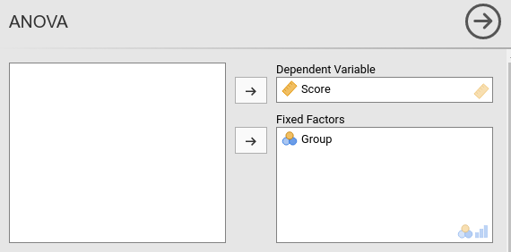

Setting the contrasts to `deviation`

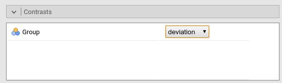

Results:

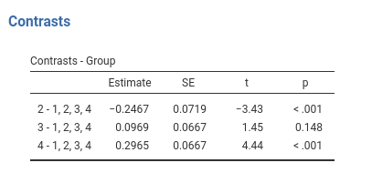

## Jamovi GAMLj GLM

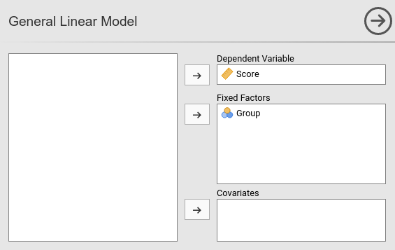

By default, GAMLj sets contrasts to `deviation`, so `default` and `deviation` is equivalent (this may change in future releases)

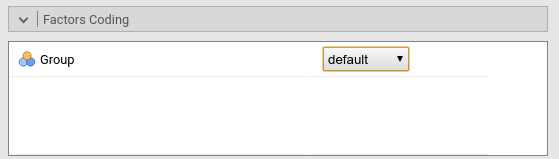

Results:

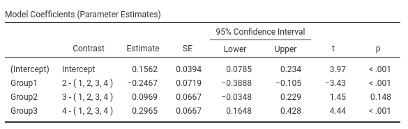

The expected means of the four groups are:

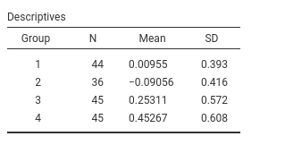

## SPSS

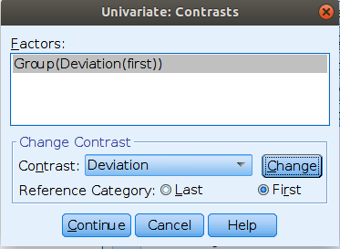

```
UNIANOVA Score BY Group
  /CONTRAST(Group)=Deviation(1)
  /METHOD=SSTYPE(3)
  /INTERCEPT=INCLUDE
  /PRINT=TEST(LMATRIX)
  /CRITERIA=ALPHA(.05)
  /DESIGN=Group.
```

[figure not shown]

## R

In R, deviation contrast is called `contr.sum`.

```r
file<-"../../data/rosetta.contrasts.csv"
dat<-read.csv2(file)

### means
(mm<-tapply(dat$Score, dat$Group, mean))
```

```
##            1            2            3            4
##  0.009545455 -0.090555556  0.253111111  0.452666667
```

```r
#### contrast=deviation or effect coding #######
dat$Group<-factor(dat$Group)
contrasts(dat$Group)<-contr.sum(4)
contrasts(dat$Group)
```

```
##   [,1] [,2] [,3]
## 1    1    0    0
## 2    0    1    0
## 3    0    0    1
## 4   -1   -1   -1
```

```r
model<-lm(Score~Group,data=dat)
summary(model)
```

```
##
## Call:
## lm(formula = Score ~ Group, data = dat)
##
## Residuals:
##      Min       1Q   Median       3Q      Max
## -2.06311 -0.27955 -0.00111  0.28531  1.65733
##
## Coefficients:
##             Estimate Std. Error t value Pr(>|t|)
## (Intercept)  0.15619    0.03936   3.969 0.000107 ***
## Group1      -0.14665    0.06719  -2.183 0.030477 *
## Group2      -0.24675    0.07193  -3.430 0.000760 ***
## Group3       0.09692    0.06670   1.453 0.148092
## ---
## Signif. codes:  0 '***' 0.001 '**' 0.01 '*' 0.05 '.' 0.1 ' ' 1
##
## Residual standard error: 0.5109 on 166 degrees of freedom
## Multiple R-squared:  0.1473, Adjusted R-squared:  0.1319
## F-statistic: 9.557 on 3 and 166 DF,  p-value: 7.399e-06
```

# Contrasts: simple

## Meaning

**Definition:** *Compares each group with the first group.*

## Jamovi ANOVA

We set the contrasts to `simple`

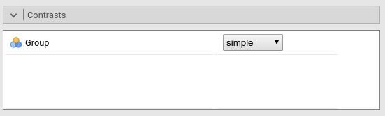

Results:

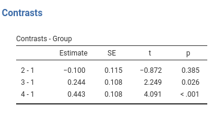

## Jamovi GAMLj GLM

Setting the contrasts in GAMLj is identical to the ANOVA module, so I omitted the screenshot from now on. Results are:

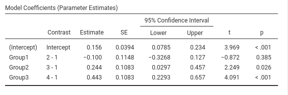

## SPSS

Please note that SPSS default sets the last group as reference group, thus to obtain the same results as before, we should set `/CONTRAST(Group)=Simple(1)`, mind the “1”“, which corresponds to”first" in the GUI options.

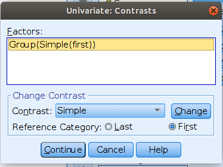

```
UNIANOVA Score BY Group
  /CONTRAST(Group)=Simple(1)
  /METHOD=SSTYPE(3)
  /INTERCEPT=INCLUDE
  /PRINT=TEST(LMATRIX)
  /CRITERIA=ALPHA(.05)
  /DESIGN=Group.
```

Results:

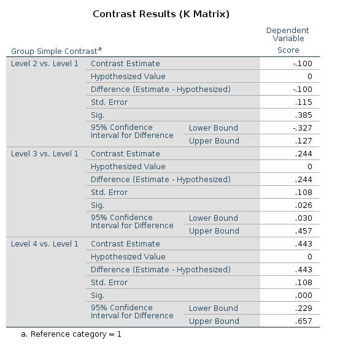

## R

In R, simple contrast is called `contr.treatment`.

```r
#### contrast=treatment or effect dummy #######
dat$Group<-factor(dat$Group)
contrasts(dat$Group)<-contr.treatment(4)
contrasts(dat$Group)
```

```
##   2 3 4
## 1 0 0 0
## 2 1 0 0
## 3 0 1 0
## 4 0 0 1
```

```r
model<-lm(Score~Group,data=dat)
summary(model)
```

```
##
## Call:
## lm(formula = Score ~ Group, data = dat)
##
## Residuals:
##      Min       1Q   Median       3Q      Max
## -2.06311 -0.27955 -0.00111  0.28531  1.65733
##
## Coefficients:
##              Estimate Std. Error t value Pr(>|t|)
## (Intercept)  0.009545   0.077018   0.124   0.9015
## Group2      -0.100101   0.114812  -0.872   0.3845
## Group3       0.243566   0.108313   2.249   0.0258 *
## Group4       0.443121   0.108313   4.091 6.68e-05 ***
## ---
## Signif. codes:  0 '***' 0.001 '**' 0.01 '*' 0.05 '.' 0.1 ' ' 1
##
## Residual standard error: 0.5109 on 166 degrees of freedom
## Multiple R-squared:  0.1473, Adjusted R-squared:  0.1319
## F-statistic: 9.557 on 3 and 166 DF,  p-value: 7.399e-06
```

# Contrast: difference

Difference and helmert contrasts are great source of confusion when one is comparing different software results. SPSS and jamovi uses the same definition of them, but R has a different implementation. Different authors uses different definitions, so be aware of which comparisons are implemented.

**Definition:***Compares each group with the average of previous groups. First group omitted.*

This is sometimes named *Reverse Helmert Coding* , cf. [UCLA idre web site](https://stats.idre.ucla.edu/r/library/r-library-contrast-coding-systems-for-categorical-variables/).

## Jamovi ANOVA

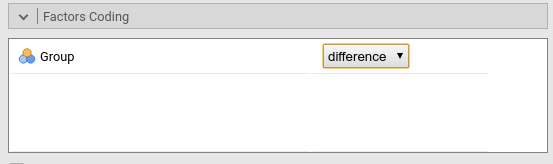

Results:

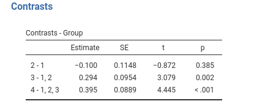

## Jamovi GAMLj GLM

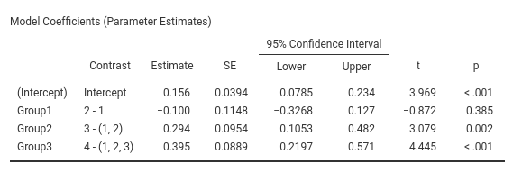

## SPSS

```
UNIANOVA Score BY Group
  /CONTRAST(Group)=DIFFERENCE
  /METHOD=SSTYPE(3)
  /INTERCEPT=INCLUDE
  /PRINT=TEST(LMATRIX)
  /CRITERIA=ALPHA(.05)
  /DESIGN=Group.
```

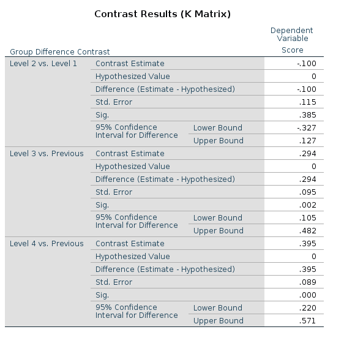

## R

The difference contrast t-test and p-value can be obtained in R using the `contr.helmert()` function. Despite the name, `contr.helmert()` implements what is usually named “Reversed Helmert contrast”. Obviously, this is perfectly fine (cf. [An R and S-Plus Companion to Applied Regression](http://www.amazon.com/gp/product/0761922806/ref=as_li_ss_tl?ie=UTF8&camp=1789&creative=390957&creativeASIN=0761922806&linkCode=as2&tag=curiousanduseful)), but one should know what the direction of the contrast is. Furthermore, the contrast weights in R are scaled differently than in SPSS or jamovi, thus the contrast values (coefficients) are not identical to the ones obtained in jamovi, but they are proportional to them (that is why the t-tests are the same).

```r
dat$Group<-factor(dat$Group)
contrasts(dat$Group)<-contr.helmert(4)
contrasts(dat$Group)
```

```
##   [,1] [,2] [,3]
## 1   -1   -1   -1
## 2    1   -1   -1
## 3    0    2   -1
## 4    0    0    3
```

```r
model<-lm(Score~Group,data=dat)
summary(model)
```

```
##
## Call:
## lm(formula = Score ~ Group, data = dat)
##
## Residuals:
##      Min       1Q   Median       3Q      Max
## -2.06311 -0.27955 -0.00111  0.28531  1.65733
##
## Coefficients:
##             Estimate Std. Error t value Pr(>|t|)
## (Intercept)  0.15619    0.03936   3.969 0.000107 ***
## Group1      -0.05005    0.05741  -0.872 0.384538
## Group2       0.09787    0.03179   3.079 0.002433 **
## Group3       0.09882    0.02223   4.445  1.6e-05 ***
## ---
## Signif. codes:  0 '***' 0.001 '**' 0.01 '*' 0.05 '.' 0.1 ' ' 1
##
## Residual standard error: 0.5109 on 166 degrees of freedom
## Multiple R-squared:  0.1473, Adjusted R-squared:  0.1319
## F-statistic: 9.557 on 3 and 166 DF,  p-value: 7.399e-06
```

To obtain the jamovi/SPSS values in R, we should multiply the coefficients obtained in R by the index of the column of the contrasts (starting from 2 because 1 is for the intercept). To make things a bit more general, we can define a *conversion vector* that works both for deviation and helmert contrasts. Let the *conversion vector* be $cv=max(c_i)+1$, where $c_i$ is a column of the contrast matrix.

```r
cv<-apply(contr.helmert(4),2,max)+1
cv
```

```
## [1] 2 3 4
```

To obtain the same coefficients in R and in jamovi/SPSS, we can multiply the model coefficients by $cv$

```r
coef(model)[c(2:4)]*cv
```

```
##     Group1     Group2     Group3
## -0.1001010  0.2936162  0.3952997
```

Or divide the contrast weights by $cv$

```r
### make a diagonal matrix with cv in the diagonal ##########
diag_cv<-matrix(rep(cv,each=4),ncol=3)

contrasts(dat$Group)<-contr.helmert(4)/diag_cv
contrasts(dat$Group)
```

```
##   [,1]       [,2]  [,3]
## 1 -0.5 -0.3333333 -0.25
## 2  0.5 -0.3333333 -0.25
## 3  0.0  0.6666667 -0.25
## 4  0.0  0.0000000  0.75
```

```r
model<-lm(Score~Group,data=dat)
summary(model)
```

```
##
## Call:
## lm(formula = Score ~ Group, data = dat)
##
## Residuals:
##      Min       1Q   Median       3Q      Max
## -2.06311 -0.27955 -0.00111  0.28531  1.65733
##
## Coefficients:
##             Estimate Std. Error t value Pr(>|t|)
## (Intercept)  0.15619    0.03936   3.969 0.000107 ***
## Group1      -0.10010    0.11481  -0.872 0.384538
## Group2       0.29362    0.09537   3.079 0.002433 **
## Group3       0.39530    0.08893   4.445  1.6e-05 ***
## ---
## Signif. codes:  0 '***' 0.001 '**' 0.01 '*' 0.05 '.' 0.1 ' ' 1
##
## Residual standard error: 0.5109 on 166 degrees of freedom
## Multiple R-squared:  0.1473, Adjusted R-squared:  0.1319
## F-statistic: 9.557 on 3 and 166 DF,  p-value: 7.399e-06
```

… and we get the same values, t-tests and p-values as in jamovi and SPSS.

# Contrast: helmert

**Definition:***Compares each group with the average of subsequent groups*

## Jamovi ANOVA

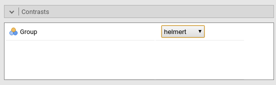

Results:

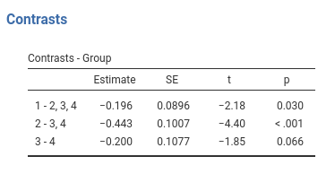

## Jamovi GAMLj GLM

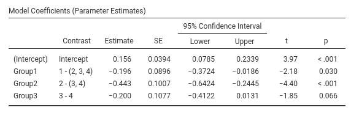

## SPSS

```
UNIANOVA Score BY Group
  /CONTRAST(Group)=HELMERT
  /METHOD=SSTYPE(3)
  /INTERCEPT=INCLUDE
  /PRINT=TEST(LMATRIX)
  /CRITERIA=ALPHA(.05)
  /DESIGN=Group.
```

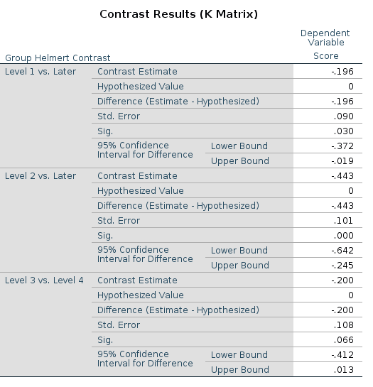

## R

R defines helmert contrast in the reverse order as compared with jamovi and SPSS, and uses a different scaling. To obtain the helmert contrast as is was defined, we should reverse `contr.helmert()` and rescale the coding as we did for the `difference` contrasts. Without rescaling, the t-test and p-values are the same as in jamovi/spss, but the estimated values are different (but proportional).

```r
dat$Group<-factor(dat$Group)
contrasts(dat$Group)<-matrix(rev(contr.helmert(4)),ncol=3)
con_weights<-contrasts(dat$Group)
con_weights
```

```
##   [,1] [,2] [,3]
## 1    3    0    0
## 2   -1    2    0
## 3   -1   -1    1
## 4   -1   -1   -1
```

```r
model<-lm(Score~Group,data=dat)
summary(model)
```

```
##
## Call:
## lm(formula = Score ~ Group, data = dat)
##
## Residuals:
##      Min       1Q   Median       3Q      Max
## -2.06311 -0.27955 -0.00111  0.28531  1.65733
##
## Coefficients:
##             Estimate Std. Error t value Pr(>|t|)
## (Intercept)  0.15619    0.03936   3.969 0.000107 ***
## Group1      -0.04888    0.02240  -2.183 0.030477 *
## Group2      -0.14781    0.03358  -4.402 1.92e-05 ***
## Group3      -0.09978    0.05385  -1.853 0.065681 .
## ---
## Signif. codes:  0 '***' 0.001 '**' 0.01 '*' 0.05 '.' 0.1 ' ' 1
##
## Residual standard error: 0.5109 on 166 degrees of freedom
## Multiple R-squared:  0.1473, Adjusted R-squared:  0.1319
## F-statistic: 9.557 on 3 and 166 DF,  p-value: 7.399e-06
```

To obtain the jamovi/SPSS values in R, we should compute $cv=max(c_i)+1$, and multiply it by the model coefficients.

```r
cv<-apply(con_weights,2,max)+1
cv
```

```
## [1] 4 3 2
```

```r
coef(model)[c(2:4)]*cv
```

```
##     Group1     Group2     Group3
## -0.1955286 -0.4434444 -0.1995556
```

Or divide the contrast weights by $cv$

```r
### make a diagonal matrix with cv in the diagonal ##########
diag_cv<-matrix(rep(cv,each=4),ncol=3)

helm<-con_weights/diag_cv
contrasts(dat$Group)<-helm
model<-lm(Score~Group,data=dat)
summary(model)
```

```
##
## Call:
## lm(formula = Score ~ Group, data = dat)
##
## Residuals:
##      Min       1Q   Median       3Q      Max
## -2.06311 -0.27955 -0.00111  0.28531  1.65733
##
## Coefficients:
##             Estimate Std. Error t value Pr(>|t|)
## (Intercept)  0.15619    0.03936   3.969 0.000107 ***
## Group1      -0.19553    0.08959  -2.183 0.030477 *
## Group2      -0.44344    0.10075  -4.402 1.92e-05 ***
## Group3      -0.19956    0.10770  -1.853 0.065681 .
## ---
## Signif. codes:  0 '***' 0.001 '**' 0.01 '*' 0.05 '.' 0.1 ' ' 1
##
## Residual standard error: 0.5109 on 166 degrees of freedom
## Multiple R-squared:  0.1473, Adjusted R-squared:  0.1319
## F-statistic: 9.557 on 3 and 166 DF,  p-value: 7.399e-06
```

… and we’re happy campers.

# Contrast: Repeated

**Definition:** *Compares each group with the subsequent group*

## Jamovi ANOVA

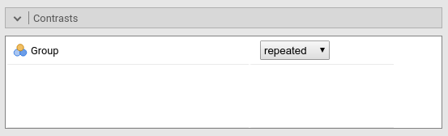

Results:

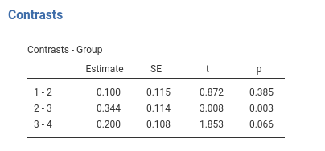

## Jamovi GAMLj GLM

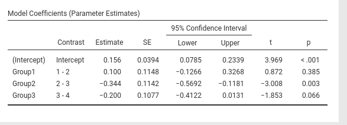

## SPSS

```
UNIANOVA Score BY Group
  /CONTRAST(Group)=REPEATED
  /METHOD=SSTYPE(3)
  /INTERCEPT=INCLUDE
  /PRINT=TEST(LMATRIX)
  /CRITERIA=ALPHA(.05)
  /DESIGN=Group.
```

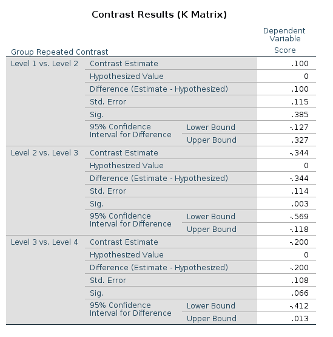

## R

R does not have an out-of-the-box contrast equivalent to `repeated` contrast. One can, howerver, define a custom coding scheme. One just needs to define a `-1 vs 1` contrast for subsequent groups as follows (this is exactly the code used by jamovi contrasts routine):

```r
nLevels<-4
repeated <- matrix(0, nrow=nLevels, ncol=nLevels-1)
for (i in seq_len(nLevels-1)) {
      repeated[1:i,i] <- (nLevels-i) / nLevels
      repeated[(i+1):nLevels,i] <- -i / nLevels
}

contrasts(dat$Group)<-repeated
summary(lm(Score~Group,data=dat))
```

```
##
## Call:
## lm(formula = Score ~ Group, data = dat)
##
## Residuals:
##      Min       1Q   Median       3Q      Max
## -2.06311 -0.27955 -0.00111  0.28531  1.65733
##
## Coefficients:
##             Estimate Std. Error t value Pr(>|t|)
## (Intercept)  0.15619    0.03936   3.969 0.000107 ***
## Group1       0.10010    0.11481   0.872 0.384538
## Group2      -0.34367    0.11424  -3.008 0.003036 **
## Group3      -0.19956    0.10770  -1.853 0.065681 .
## ---
## Signif. codes:  0 '***' 0.001 '**' 0.01 '*' 0.05 '.' 0.1 ' ' 1
##
## Residual standard error: 0.5109 on 166 degrees of freedom
## Multiple R-squared:  0.1473, Adjusted R-squared:  0.1319
## F-statistic: 9.557 on 3 and 166 DF,  p-value: 7.399e-06
```

… and we’re just fine.

# Contrast: polynomial

**Definition:** *Test polynomial (linear, quadratic, cubic, etc.) trends in the means pattern*

## Jamovi ANOVA

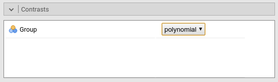

Results:

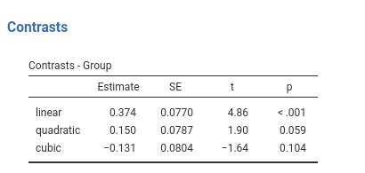

## Jamovi GAMLj GLM

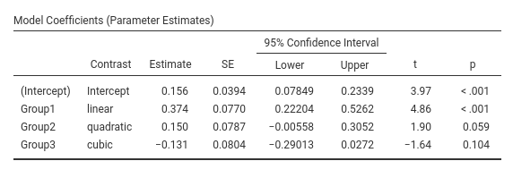

## SPSS

```
UNIANOVA Score BY Group
  /CONTRAST(Group)=POLYNOMIAL
  /METHOD=SSTYPE(3)
  /INTERCEPT=INCLUDE
  /PRINT=TEST(LMATRIX)
  /CRITERIA=ALPHA(.05)
  /DESIGN=Group.
```

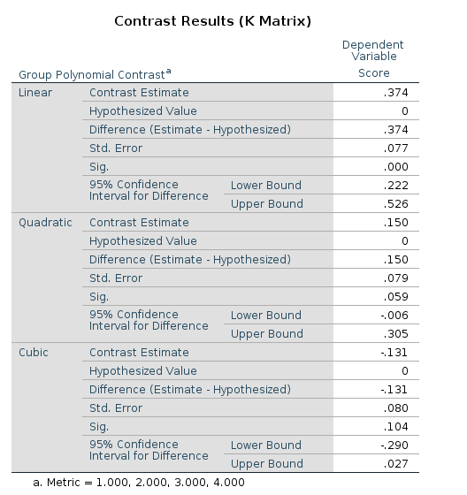

## R

R has an out-of-the-box contrast named `contr.poly()` contrast. it works like a sharm.

```r
contrasts(dat$Group)<-contr.poly(4)
summary(lm(Score~Group,data=dat))
```

```
##
## Call:
## lm(formula = Score ~ Group, data = dat)
##
## Residuals:
##      Min       1Q   Median       3Q      Max
## -2.06311 -0.27955 -0.00111  0.28531  1.65733
##
## Coefficients:
##             Estimate Std. Error t value Pr(>|t|)
## (Intercept)  0.15619    0.03936   3.969 0.000107 ***
## Group.L      0.37410    0.07702   4.857 2.73e-06 ***
## Group.Q      0.14983    0.07871   1.904 0.058702 .
## Group.C     -0.13145    0.08037  -1.636 0.103809
## ---
## Signif. codes:  0 '***' 0.001 '**' 0.01 '*' 0.05 '.' 0.1 ' ' 1
##
## Residual standard error: 0.5109 on 166 degrees of freedom
## Multiple R-squared:  0.1473, Adjusted R-squared:  0.1319
## F-statistic: 9.557 on 3 and 166 DF,  p-value: 7.399e-06
```

… and we can sleep like babies.

# Comments?

Got comments, issues or spotted a bug? Please open an issue on GAMLj at github“ or send me an email